# Single cell RNA-seq of cells labeled with AAV1_P5

Lukas PM Kremer

8/17/2020

Loading required packages and defining some settings

```r
library(tidyverse)
library(here)
library(Matrix)
library(magrittr)
library(ggpointdensity)
library(patchwork)
library(DESeq2)
library(sparseMatrixStats)
library(Seurat)
```

Some aesthetic choices to determine the look of our plots

```r
theme_set(theme_bw() + theme(text = element_text(family = 'Arial'),
                             panel.grid.minor = element_blank(),    # remove axis grid
                             panel.grid.major = element_blank(),
                             strip.background = element_blank(),    # remove silly gray bg of facet title
                             strip.text = element_text(hjust = 0)   # left-justify facets
))

celltype_colors <- c("ENB"="#e8a623ff", "LNB"="#e17827ff", "TAP"="#20854EFF", "aNSC"="#BC3C29FF",
                     "qNSC"="#0072B5FF", "Ep"="#7876B1FF", "other"="gray50", "MG"="#6F99ADFF")
```

# Read the count matrix and corresponding metadata

```r
metadata <- read_tsv(here("03_single-cell-RNA-seq", "count_matrix", "metadata.tsv.gz"),
                     col_types = "ccnnncnnclnnncccnnc") %>%
  mutate(transgene_exp = fct_relevel(transgene_exp, "eYFP- NeoR-", "eYFP- NeoR+", "eYFP+ NeoR+"),
         celltype = fct_relevel(celltype, c("qNSC", "aNSC", "TAP", "ENB", "LNB", "Ep", "other")))
```

```r
colNames_genes <- read_tsv(here("03_single-cell-RNA-seq", "count_matrix", "colNames_genes.tsv.gz"),
                           col_names = c("gene_id_version", "gene_symbol"),
                           col_types = "cc")
symbol2ensg <- colNames_genes %>% dplyr::select(2, 1) %>% deframe()
ensg2symbol <- colNames_genes %>% deframe()
rowNames_cells <- read_tsv(here("03_single-cell-RNA-seq", "count_matrix", "rowNames_cellBarcodes.tsv.gz"),
                           col_names = "barcode", col_types = "c")

raw_counts <- readMM(here("03_single-cell-RNA-seq", "count_matrix", "raw_counts_cellXgene.mtx.gz")) %>%
  set_rownames(rowNames_cells$barcode) %>%
  set_colnames(colNames_genes$gene_id_version) %>%
  as("dgCMatrix")

trans_counts <- log1p(1e4 * raw_counts / sparseMatrixStats::rowSums2(raw_counts))
```

A little test plot showing the number of UMIs and genes per cell

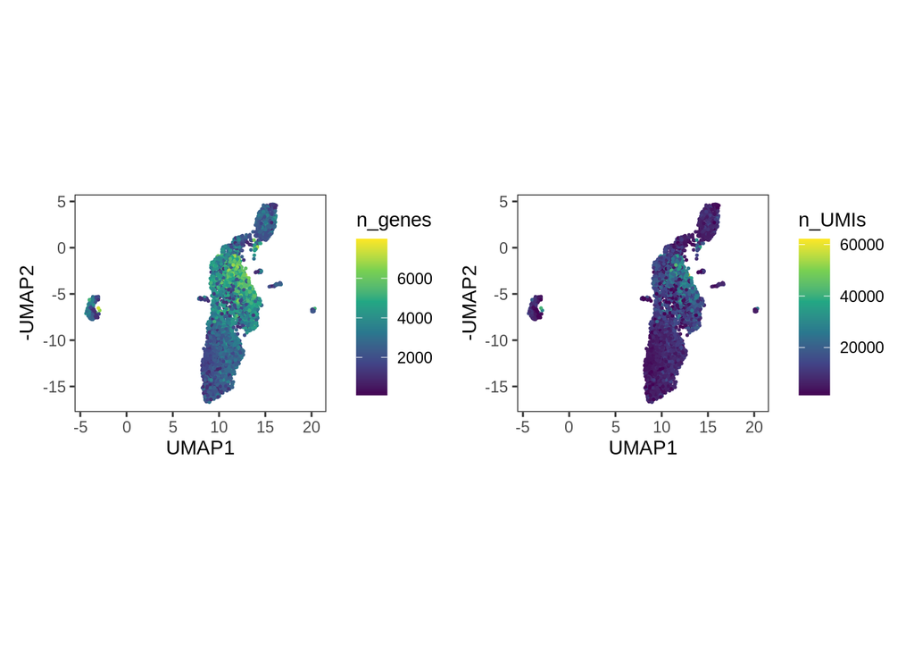

```r
(metadata %>%
  ggplot(aes(x = UMAP1, y = -UMAP2, color = n_genes))) +
(metadata %>%
  ggplot(aes(x = UMAP1, y = -UMAP2, color = n_UMIs))) &
  geom_point(size=.3) &
  coord_fixed() &
  scale_color_viridis_c()
```

## Figure 3b - UMAP of all cells, colored by cell type

Plot the UMAP that shows our cell types

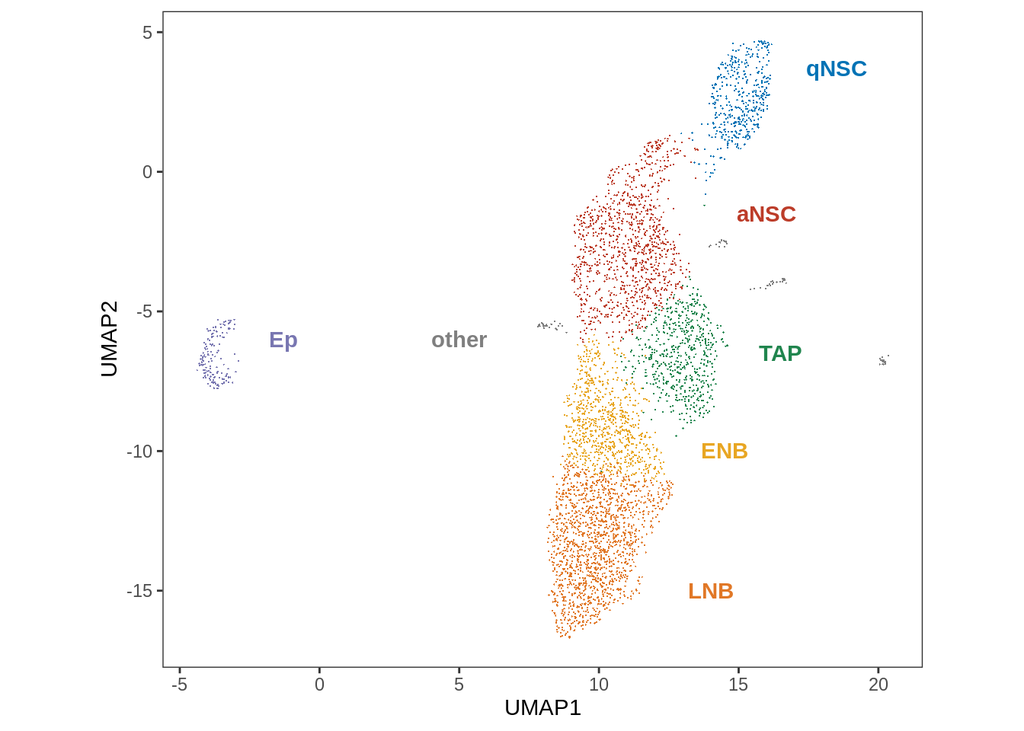

```r
# define the location and text of the cell type labels to be added to the UMAP
ct_plotlabs <- tribble(
  ~celltype, ~UMAP1, ~UMAP2,
  "qNSC", 18.5, -3.7,
  "aNSC", 16, 1.5,
  "TAP", 16.5, 6.5,
  "ENB", 14.5, 10,
  "LNB", 14, 15,
  "Ep", -1.3, 6,
  "other", 5, 6,
)

metadata %>%
  ggplot(aes(y = -UMAP2, x = UMAP1, color = celltype)) +
  geom_point(size = .4, stroke = 0) +
  aes(label = celltype) +
  geom_text(data = ct_plotlabs, fontface="bold") +
  coord_fixed() +
  scale_color_manual(values = celltype_colors) +
  theme(legend.position = "none") +
  labs(x = "UMAP1", y = "UMAP2")
```

... and the small pie charts that show the proportion of off-target cells in each replicate. Since we're interested in the performance of AAV1_P5, we discard all unlabeled (eYFP negative) cells before calculating this proportion.  
In this case, off-target cells are defined as cells that are not in a cluster that is part of the main lineage (qNSC -> LNB).

```r
off_target <- metadata %>%
  filter(eYFP_counts > 0) %>%
  group_by(sample, in_lineage) %>%
  tally() %>% ungroup() %>%
  pivot_wider(names_from = "in_lineage", values_from = "n") %>%
  mutate(label = paste0(formatC(100 * `FALSE` / (`FALSE` + `TRUE`), format = "f", digits = 1), "%"))

off_target
```

```
## # A tibble: 2 x 4
##   sample    `FALSE` `TRUE` label
##   <chr>       <int>  <int> <chr>
## 1 sample #1      56    524 9.7%
## 2 sample #2      56   1996 2.7%
```

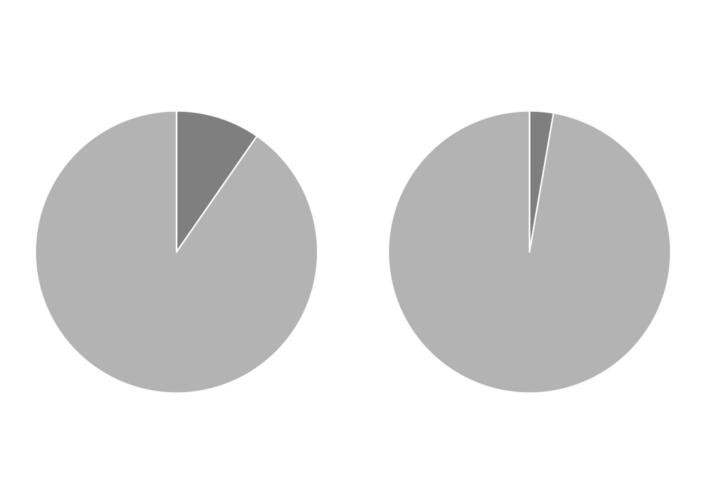

```r
pie1 <- metadata %>% filter(sample == "sample #1" & eYFP_counts > 0) %>%
  left_join(off_target, by = "sample") %>%
  ggplot(aes(x = "", fill = in_lineage, label = label)) +
  geom_bar(width=1, color="white")

pie2 <- metadata %>% filter(sample == "sample #2" & eYFP_counts > 0) %>%
  left_join(off_target, by = "sample") %>%
  ggplot(aes(x = "", fill = in_lineage, label = label)) +
  geom_bar(width=1, color="white")

(pie1 + pie2) &
  scale_fill_manual(values = c("TRUE"="gray70", "FALSE"="gray50")) &
  coord_polar("y", start=0, direction=-1L) &
  theme_void() &
  theme(legend.position = "none", strip.text = element_text(hjust=1))
```

## Supplementary Figure S4h - origin of cells

[figure not shown]

```r
# First, calculate the 2D kernel density estimate in the UMAP for both samples
data <- tibble(x = metadata$UMAP1, y = metadata$UMAP2, group = metadata$batch)
data.group1 <- dplyr::filter(data, group == "WT1")
data.group2 <- dplyr::filter(data, group == "WT2")

adjust <- .75  # multiplicative bandwith adjustment
base.args.group1 <- list(
  x = data.group1$x,
  y = data.group1$y,
  lims = c(range(data$x), range(data$y)))
base.args.group2 <- list(
  x = data.group2$x,
  y = data.group2$y,
  lims = c(range(data$x), range(data$y)))
method.args <- list(
  n = 100,
  h = c(MASS::bandwidth.nrd(data$x), MASS::bandwidth.nrd(data$y)) * adjust
)

dens.group1 <- do.call(MASS::kde2d, c(base.args.group1, method.args))
dens.group2 <- do.call(MASS::kde2d, c(base.args.group2, method.args))

ix <- findInterval(data$x, dens.group1$x)
iy <- findInterval(data$y, dens.group1$y)
ii <- cbind(ix, iy)
data$density.group1 <- dens.group1$z[ii]
data$density.group2 <- dens.group2$z[ii]

# For every cell, subtract the two densities at this position to get the color
data %>%
  ggplot(aes(x = x, y = -y, color = density.group1 - density.group2)) +
  geom_point(size = .3) +
  scale_color_gradient2(midpoint = 0, mid = "gray70", low = "#000099", high = "#FF9900") +
  coord_fixed() +
  geom_text(data = ct_plotlabs,
            mapping = aes(x = UMAP1, y = -UMAP2, label = celltype),
            inherit.aes = F, fontface = "bold") +
  theme(legend.position = c(0.25, 0.25), legend.background = element_blank()) +
  labs(x = "UMAP1", y = "UMAP2", color = "Δ cell density")
```

## Supplementary Figure S4i - highlighting cells that express eYFP

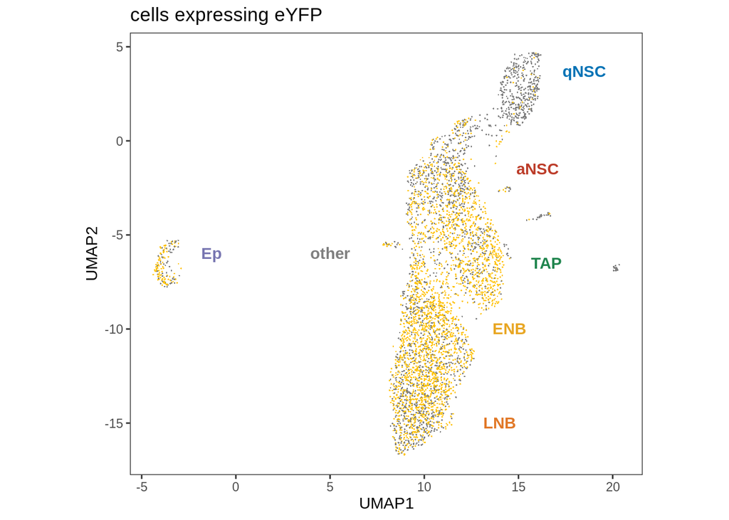

```r
metadata %>%
  slice_sample(prop=1) %>% # shuffle point plotting order
  ggplot(aes(y = -UMAP2, x = UMAP1, color = eYFP_counts > 0)) +
  geom_point(size=.5, stroke=0) +
  geom_text(data = ct_plotlabs, fontface="bold",
            mapping = aes(y = -UMAP2, x = UMAP1, color = celltype , label = celltype)) +
  coord_fixed() +
  labs(title = "cells expressing eYFP") +
  theme(legend.position = "none") +
  scale_color_manual(values=c(celltype_colors, c("TRUE"="#ffc40c", "FALSE"="gray50"))) +
  labs(x = "UMAP1", y = "UMAP2")
```

## Supplementary Figure S4j- highlighting cells that express Cre

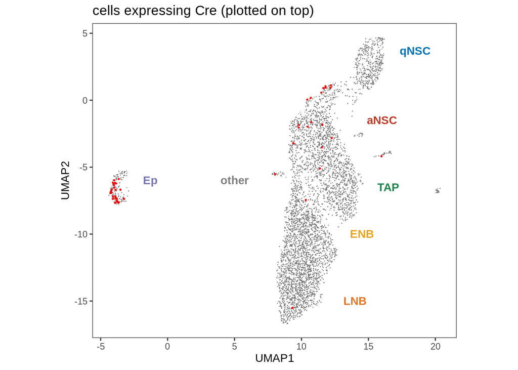

```r
metadata %>%
  filter(Cre_counts == 0) %>%
  ggplot(aes(y = -UMAP2, x = UMAP1)) +
  geom_point(size=.5, stroke=0, color = "gray50") +
  geom_point(size=1, stroke = 0, color="red", data = filter(metadata, Cre_counts > 0)) +
  geom_text(data = ct_plotlabs, fontface="bold",
            mapping = aes(y = -UMAP2, x = UMAP1, color = celltype , label = celltype)) +
  coord_fixed() +
  labs(title = "cells expressing Cre (plotted on top)") +
  theme(legend.position = "none") +
  scale_color_manual(values=c(celltype_colors, c("TRUE"="#ffc40c", "FALSE"="gray50"))) +
  labs(x = "UMAP1", y = "UMAP2")
```

## Figure 3c - proportion of cells that express eYFP or NeoR

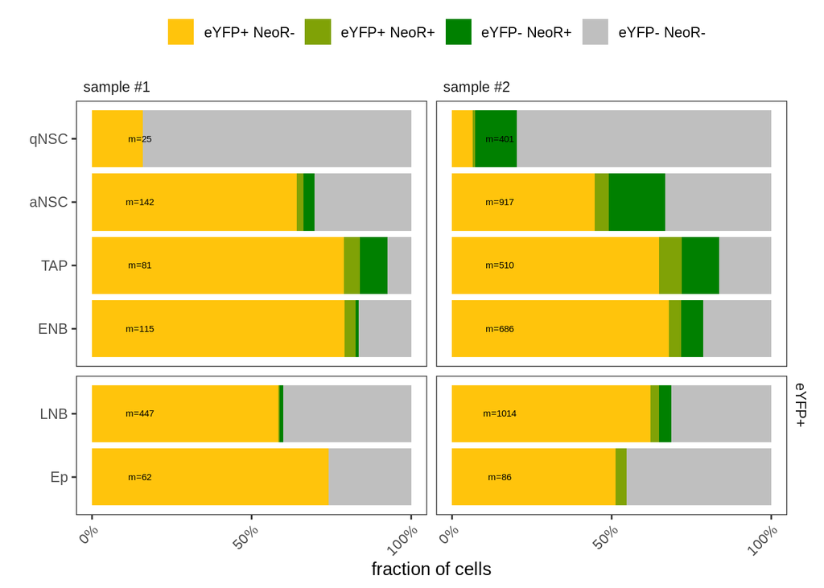

```r
group_counts <- metadata %>%
  mutate(sorting = if_else(celltype %in% c("LNB", "Ep"), "eYFP+", "")) %>%
  filter(celltype != "other") %>%
  group_by(celltype, sample, sorting) %>%
  tally()

transgene_fill <- c("eYFP- NeoR+"="#008000", "eYFP+ NeoR+"="#80A206", "eYFP- NeoR-"="gray75", "eYFP+ NeoR-"="#ffc40c")

metadata %>%
  filter(celltype != "other") %>%
  mutate(transgene_exp = fct_relevel(transgene_exp, "eYFP- NeoR-", "eYFP- NeoR+", "eYFP+ NeoR+"),
         sorting = if_else(celltype %in% c("LNB", "Ep"), "eYFP+", "")) %>%
  ggplot(aes(y = fct_rev(celltype), fill = transgene_exp)) +
  geom_bar(position="fill") +
  geom_text(data = group_counts, size = 2,
            mapping = aes(y = fct_rev(celltype), x = .15, label = str_c("m=", n)),
            inherit.aes = F) +
  facet_grid(sorting ~ sample, space = "free", scales='free_y') +
  scale_fill_manual(values=transgene_fill) +
  scale_x_continuous(labels = scales::percent_format(accuracy = 1),
                     limits = c(0,1), breaks=0:2/2, minor_breaks = 0:4/4) +
  labs(x = "fraction of cells", y = "", fill = "") +
  theme(legend.position = "top", legend.direction = "horizontal",
        axis.text.x = element_text(angle = 45, hjust = 1)) +
  guides(fill = guide_legend(reverse = TRUE))
```

## Figure 3d - boxplots + beeswarm plots of UMIs per cell

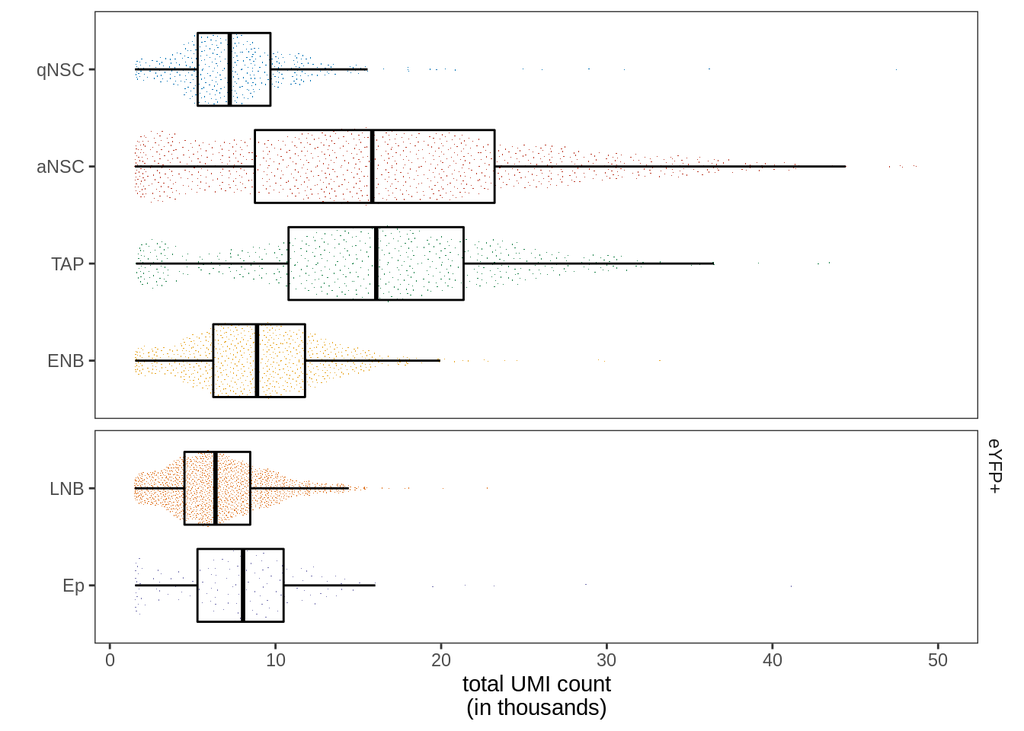

```r
metadata %>%
  mutate(sorting = if_else(celltype %in% c("LNB", "Ep"), "eYFP+", "")) %>%
  filter(celltype != "other") %>%
  ggplot(aes(y = fct_rev(celltype), x = n_UMIs/1000, color = celltype)) +
  ggbeeswarm::geom_quasirandom(size = .25, stroke = 0, groupOnX=F) +
  geom_boxplot(color = "black", outlier.shape = NA, fill = NA, size = .5) +
  scale_color_manual(values = celltype_colors) +
  facet_grid(sorting ~ ., scales = "free", space = "free") +
  labs(y="", x = "total UMI count\n(in thousands)") +
  theme(legend.position = "none") +
  xlim(c(NA, 50))
## Warning: Removed 5 rows containing non-finite values (stat_boxplot).
## Warning: Removed 5 rows containing missing values (position_quasirandom).
```